# Sahadeo_Lab6

Rishi Sahadeo

2025-04-24

## Use the random sample with 200 movies you had from homework 4 to test

```r
set.seed(12345)

boxoffice <- read_csv("C:/Users/supaq/OneDrive/Desktop/Rutgers Courses/Statistical Inference for Data Science/Lab 4/movie_boxoffice-1.csv")
sample_200 <- boxoffice %>%
  sample_n(size = 200)

sample_200
```

```
## # A tibble: 200 × 7
##    Movie                 Month   Day  Year Budget Domestic_Gross Worldwide_Gross
##    <chr>                 <chr> <dbl> <dbl>  <dbl>          <dbl>           <dbl>
##  1 Dragonslayer          Jun      26  1981   18            6               6
##  2 Wag the Dog           Dec      25  1997   15           43.1            64.3
##  3 Turbulence            Jan      10  1997   55           11.5            11.5
##  4 Severance             May      18  2007   10            0.137           5.95
##  5 Diary of a Wimpy Kid… May      19  2017   22           20.7            35.4
##  6 Beavis and Butt-Head… Dec      20  1996   12           63.1            63.1
##  7 Walk the Line         Nov      18  2005   29          120.            188.
##  8 Mondays in the Sun    Jul      25  2003    4            0.146           0.146
##  9 The Best Little Whor… Jul      23  1982   20.5         69.7            69.7
## 10 The Bone Collector    Nov       5  1999   48           66.5           151.
## # ℹ 190 more rows
```

### 1. Whether the average global box office earnings of all movies is different than $90 million.

Resample/Simulation Method

```r
# Null Distribution where mean = 90
null_dist <- sample_200 %>%
  specify(response = Worldwide_Gross) %>%
  hypothesize(null = "point", mu = 90) %>%
  generate(reps = 1000, type = "bootstrap") %>%
  calculate(stat = "mean")

# Obs sample mean
obs_mean <- sample_200 %>%
  specify(response = Worldwide_Gross) %>%
  calculate(stat = "mean")

obs_mean
```

```
## Response: Worldwide_Gross (numeric)
## # A tibble: 1 × 1
##    stat
##   <dbl>
## 1  102.
```

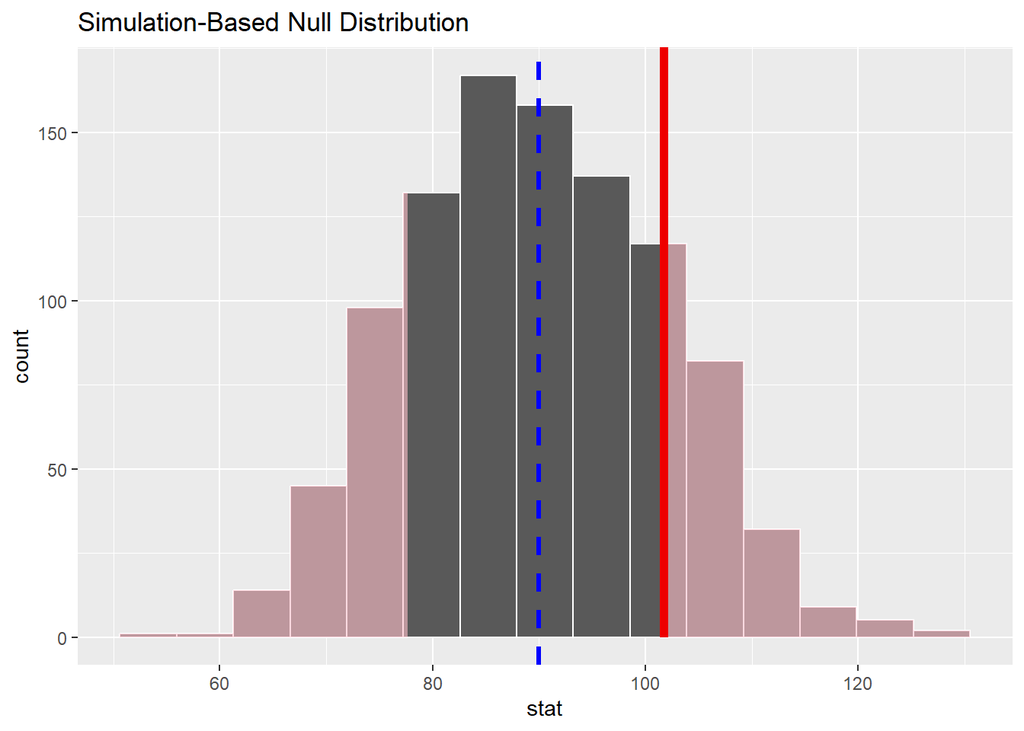

```r
# Histogram of null w/ shade p_value
visualise(null_dist) +
  shade_p_value(obs_stat = obs_mean, direction = "two-sided" ) +
  geom_vline(xintercept = 90, color = "blue", linetype = "dashed",
             linewidth = 1.2)
```

```r
# P-value
get_p_value(null_dist, obs_stat = obs_mean, direction = "two-sided")
```

```
## # A tibble: 1 × 1
##   p_value
##     <dbl>
## 1   0.346
```

We do not have enough evidence to say the average worldwide gross is different from $90 million in the population of movies.

With a P-value of 0.346, we fail to reject the null hypothesis.

The observed mean of $102 Million is not signigicantly different from the hypothesized mean of $90 million.

Theoretical Method

```r
x_bar <- mean(sample_200$Worldwide_Gross)
stdev <- sd(sample_200$Worldwide_Gross)
n <- nrow(sample_200)

# Standard Error
se <- stdev / sqrt(n)

# Z-Score
z <- (x_bar - 90) / se

# Two_tailed p-value
p_val_theo <- 2 * pnorm(-abs(z))

x_bar
```

```
## [1] 101.7361
```

```r
stdev
```

```
## [1] 167.9463
```

```r
se
```

```
## [1] 11.8756
```

```r
z
```

```
## [1] 0.9882538
```

```r
p_val_theo
```

```
## [1] 0.3230284
```

The p-value of 0.323 is greater than 0.05 so we fail to reject the null hypothesis. Using the theoretical method we conclude, there is not enough evidence to say the average global box office is different from $90 Million

Both the simulation method and the theoretical method lead to the same conclusion. the observed average is ~$102 Million is not significantly different from the hypothesized mean of $90 Million.

### 2. Whether the average global box office earnings in the summer (June, July and August) is higher than the average global box office earnings in the rest of the year

Is the average global box office for summer movies higher than the average for non-summer movies?

Null Hypothesis: mu_summer = mu_nonsummer Alternative Hypothesis: mu_summer > mu_nonsummer

Simulation/Resample Method

```r
sample_200 <- sample_200 %>%
  mutate(
    Season = if_else(Month %in% c("Jun", "Jul", "Aug"), "Summer", "Non-Summer")
  )

table(sample_200$Season)
```

```
##
## Non-Summer     Summer
##        151         49
```

```r
obs_diff <- sample_200 %>%
  specify(formula = Worldwide_Gross ~ Season) %>%
  calculate(stat = "diff in means", order = c("Summer", "Non-Summer"))
obs_diff
```

```
## Response: Worldwide_Gross (numeric)
## Explanatory: Season (factor)
## # A tibble: 1 × 1
##    stat
##   <dbl>
## 1  18.1
```

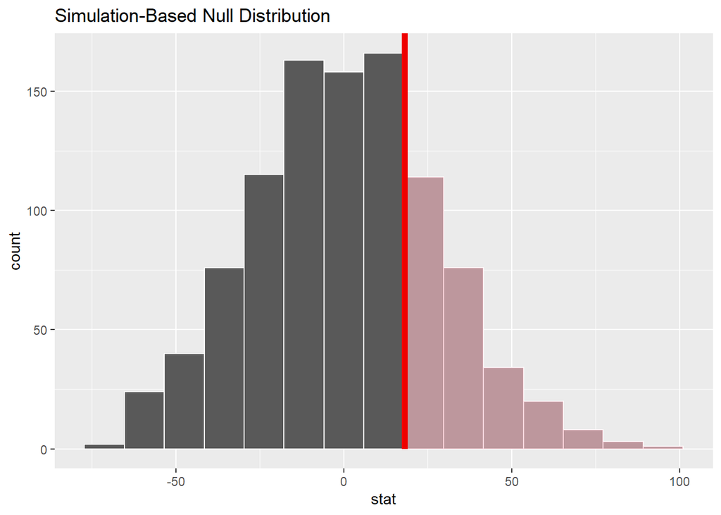

```r
null_dist_diff <- sample_200 %>%
  specify(formula = Worldwide_Gross ~ Season) %>%
  hypothesize(null = "independence") %>%
  generate(reps = 1000, type = "permute") %>%
  calculate(stat = "diff in means", order = c("Summer", "Non-Summer"))

visualize(null_dist_diff) +
  shade_p_value(obs_stat =  obs_diff, direction = "right")
```

```r
get_p_value(null_dist_diff, obs_stat = obs_diff, direction = "right")
```

```
## # A tibble: 1 × 1
##   p_value
##     <dbl>
## 1   0.255
```

25.5% of the simulated differences under the null were at least as extreme as the observed difference of $18.1 Million.

Since the p-value = 0.255, We fail to reject the null hypothesis. There is not enough evidence to conclude that summer movies earn more than non summer movies

Theoretical Method

```r
summer <- sample_200 %>% filter(Season == "Summer")
nonsummer <- sample_200 %>% filter(Season == "Non-Summer")

mean_summer <- mean(summer$Worldwide_Gross)
mean_nonsummer <- mean(nonsummer$Worldwide_Gross)

sd_summer <- sd(summer$Worldwide_Gross)
sd_nonsummer <- sd(nonsummer$Worldwide_Gross)

n_summer <- nrow(summer)
n_nonsummer <- nrow(nonsummer)

se_diff <- sqrt((sd_summer^2 / n_summer) + (sd_nonsummer^2 / n_nonsummer))

z <- (mean_summer - mean_nonsummer) / se_diff

p_val_theo <- pnorm(z, lower.tail = FALSE)

mean_summer
```

```
## [1] 115.4036
```

```r
mean_nonsummer
```

```
## [1] 97.30096
```

```r
se_diff
```

```
## [1] 29.6376
```

```r
z
```

```
## [1] 0.6107991
```

```r
p_val_theo
```

```
## [1] 0.2706663
```

Using the theoretical method, the p-value is 0.271. This means we fail to reject the null hypothesis. Even though summer movies earned more on average in this sample, the difference isn’t large enough to be statistically significant.

Using both methods, we do not have sufficient evidence to say that summer movies earn more than non-summer movies.

### 3. Whether the proportion of all movies whose global box office earning exceeds budget is different than 70%.

Let p be the proportion of all movies in the sample where Worldwide_Gross > Budget.

Null hypothesis: p = 0.70 Alternative hypothesis: p != 0.70

Simulation/Resample Method

```r
sample_200 <- sample_200 %>%
  mutate(
    Profit = if_else(Worldwide_Gross > Budget, "AboveBudget", "NotAboveBudget")
  )

table(sample_200$Profit)
```

```
##
##    AboveBudget NotAboveBudget
##            127             73
```

```r
obs_budget <- sample_200 %>%
  specify(response = Profit, success = "AboveBudget") %>%
  calculate(stat = "prop")
obs_budget
```

```
## Response: Profit (factor)
## # A tibble: 1 × 1
##    stat
##   <dbl>
## 1 0.635
```

```r
null_dist_bud <- sample_200 %>%
  specify(response = Profit, success = "AboveBudget") %>%
  hypothesize(null = "point", p = 0.70) %>%
  generate(reps = 1000, type = "simulate") %>%
  calculate(stat = "prop")
```

```
## The `"simulate"` generation type has been renamed to `"draw"`. Use `type =
## "draw"` instead to quiet this message.
```

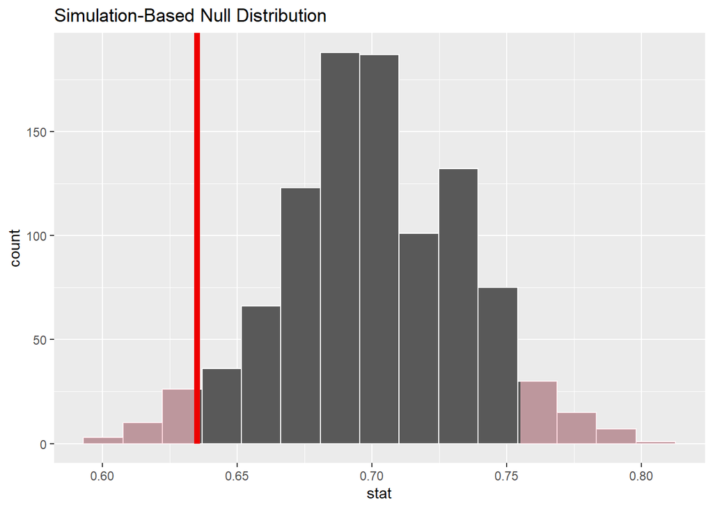

```r
visualise(null_dist_bud) +
  shade_p_value(obs_stat = obs_budget, direction = "two-sided")
```

```r
get_p_value(null_dist_bud, obs_stat = obs_budget, direction = "two-sided")
```

```
## # A tibble: 1 × 1
##   p_value
##     <dbl>
## 1   0.078
```

Since the p-value = 0.078, we fail the reject the null hypothesis. Although 0.635 is lower than 0.70, the difference is not statistically significant at the 0.05 significant level

Theoretical Method

```r
p_hat <- 127/200
p_0 <- 0.70
n <- 200

se <- sqrt(p_0 * (1 - p_0) / n)

z <- (p_hat - p_0) / se

p_val_theo <- 2 * pnorm(-abs(z))

p_hat
```

```
## [1] 0.635
```

```r
se
```

```
## [1] 0.0324037
```

```r
z
```

```
## [1] -2.005944
```

```r
p_val_theo
```

```
## [1] 0.04486227
```

Since the p_value of the theoretical method is 0.0449, this statistically significant at 0.05 level. We reject the null hypothesis

There is enough evidence to suggest that the proportion of profitable movies is different from 70%

### 4. Whether the proportion of movies released from 1980 to 1999 whose global box office earning exceeds budget is lower than the proportion of movies released from 2000 and 2018 whose global box office earning exceeds budget.

Let: p80_90 = proportion of 1980- 1999 movies above budget p00_10 = proportion for 2000 - 2018 movies above budget

Null Hypothesis: p80_90 = p00_10 Alternative Hypothesis: p80_90 < p00_10

```r
sample_200 <- sample_200 %>%
  mutate(
    Period = case_when(
      Year >= 1980 & Year <= 1999 ~ "1980-1999",
      Year >= 2000 & Year <= 2018 ~ "2000-2018",
      TRUE ~ "Other"
    )
  ) %>%
  filter(Period != "Other")

table(sample_200$Period)
```

```
##
## 1980-1999 2000-2018
##        48       152
```

```r
table(sample_200$Period, sample_200$Profit)
```

```
##
##             AboveBudget NotAboveBudget
##   1980-1999          33             15
##   2000-2018          94             58
```

Simulation Method

```r
obs_range <- sample_200 %>%
  specify(Profit ~ Period, success = "AboveBudget") %>%
  calculate(stat = "diff in props", order = c("1980-1999", "2000-2018"))
obs_range
```

```
## Response: Profit (factor)
## Explanatory: Period (factor)
## # A tibble: 1 × 1
##     stat
##    <dbl>
## 1 0.0691
```

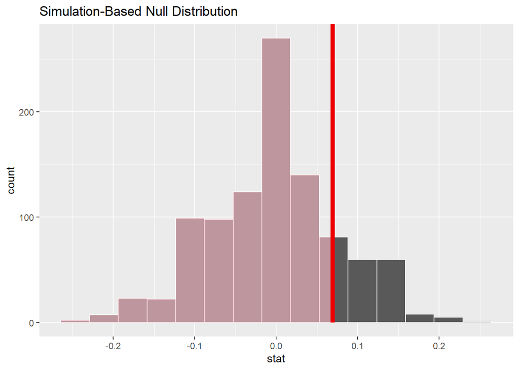

```r
null_dist_range <- sample_200 %>%
  specify(Profit ~ Period, success = "AboveBudget") %>%
  hypothesize(null = "independence") %>%
  generate(reps = 1000, type = "permute") %>%
  calculate(stat = "diff in props", order = c("1980-1999", "2000-2018"))

visualise(null_dist_range) +
  shade_p_value(obs_stat = obs_range, direction = "left")
```

```r
get_p_value(null_dist_range, obs_stat = obs_range, direction = "left")
```

```
## # A tibble: 1 × 1
##   p_value
##     <dbl>
## 1   0.866
```

The observed difference in proportions is 0.0691. Older movies actually had a higher proportion of profits than newer movies.

With a p-value of 0.866, we fail to reject the null. There is no evidence that older movies had a lower proportion of profitable releases than newer movies. The data suggests the opposite.

Theoretical Method

```r
x1 <- 33
n1 <- 48
p1 <- x1 / n1

x2 <- 94
n2 <- 152
p2 <- x2/n2

p_pool <- (x1+x2) / (n1+n2)

se <- sqrt(p_pool * (1-p_pool) * (1/n1 + 1/n2))

z <- (p1 - p2) / se

p_val_range <- pnorm(z, lower.tail = TRUE)

p1
```

```
## [1] 0.6875
```

```r
p2
```

```
## [1] 0.6184211
```

```r
p_pool
```

```
## [1] 0.635
```

```r
se
```

```
## [1] 0.07970873
```

```r
z
```

```
## [1] 0.8666422
```

```r
p_val_range
```

```
## [1] 0.806931
```

With a p-value of 0.806 we again fail to reject the null using the theoretical method, aligning with the simulation method.

There is no evidence that older movies were less profitable than newer ones. The data shows the opposite, though not significantly